# POLIST_01_notebook_exploratory_data_analysis

## Table of contents :

- I - Data-cleaning
  - 1 - Handling missing values for each dataframe
  - 2 - Merge dataframes
- II - Overview
  - 1 - Numerical variable
  - 2 - Categorical variable
- III - Feature engineering
  - 1 - Sellers
  - 2 - Customers
  - 3 - Transaction times
- IV - EDA
  - 1 - Univariate analysis
    - 1.1 - Quantitative variable
    - 1.2 - Qualitative variable
  - 2 - Multivariate analysis
  - 3 - Factorial analysis
- V - RFM segmentation
  - 1 - Preprocessing
  - 2 - RFM score
  - 3 - RFM segmentation
  - 4 - Segment analysis
- VI - Build modelization subset
  - 1 - Feature overview per dataset
  - 2 - Feature engineering
  - 3 - Cohort analysis
  - 4 - Modelization dataset

```python
# Olist module
import sys
sys.path.append("..")
from utils.olist import *
```

# I - Data-cleaning

## 1 - Handling missing values for each dataframe

### 1.1 - Display NaN count per dataframe

```python
# keywords characterizing the different input files
csv_keywords = ['payments',
                'products',
                'orders',
                'items',
                'sellers',
                'geolocation',
                'customer',
                'reviews']

# Import csv file for each keywords (return a tuple which contains dataframe & csv filename as str)
input_files_by_keywords = {keyword: csv_reader(keyword,
                                               folder_path='../data/csv/',
                                               verbose=False) for keyword in csv_keywords}

# Number of lines of all csv files
total_rows = []

# Print NaN count for each input file
for keyword, input_tuple in input_files_by_keywords.items():
    df, csv_filename = input_tuple
    rows, cols = df.shape
    print('\n')
    file_title = f'- {keyword.capitalize()} : {csv_filename} ({read_int_cleaner(rows)} rows,  {cols} columns) -'
    print('-'*len(file_title))
    print(file_title)
    print('-'*len(file_title))
    display_nan_count_for_each_col(df, margin_size=95)
    total_rows.append(rows)

# Only 1/3 csv files contains NaN (concern orders & products files)
# N.B :
# - ideally we could :
#   - train classification models (one for each type of csv file) for the missing qualitative variables
#   - Perform imputations with NMF or linear regression

total_data = 'Total amount of data : '
print('\n')
print('-'*len(total_data))
print(f'{total_data:-<95}   {read_int_cleaner(sum(total_rows))} rows')
print('-'*len(total_data))
```

```
--------------------------------------------------------------------------
- Payments : olist_order_payments_dataset.csv (103 886 rows,  5 columns) -
--------------------------------------------------------------------------
order_id--------------------------------------------------------------------------------------- 0  (0.0%)
payment_sequential----------------------------------------------------------------------------- 0  (0.0%)
payment_type----------------------------------------------------------------------------------- 0  (0.0%)
payment_installments--------------------------------------------------------------------------- 0  (0.0%)
payment_value---------------------------------------------------------------------------------- 0  (0.0%)


-------------------------------------------------------------------
- Products : olist_products_dataset.csv (32 951 rows,  9 columns) -
-------------------------------------------------------------------
product_id------------------------------------------------------------------------------------- 0  (0.0%)
product_category_name-------------------------------------------------------------------------- 610  (1.9%)
product_name_lenght---------------------------------------------------------------------------- 610  (1.9%)
product_description_lenght--------------------------------------------------------------------- 610  (1.9%)
product_photos_qty----------------------------------------------------------------------------- 610  (1.9%)
product_weight_g------------------------------------------------------------------------------- 2  (0.0%)
product_length_cm------------------------------------------------------------------------------ 2  (0.0%)
product_height_cm------------------------------------------------------------------------------ 2  (0.0%)
product_width_cm------------------------------------------------------------------------------- 2  (0.0%)


---------------------------------------------------------------
- Orders : olist_orders_dataset.csv (99 441 rows,  8 columns) -
---------------------------------------------------------------
order_id--------------------------------------------------------------------------------------- 0  (0.0%)
customer_id------------------------------------------------------------------------------------ 0  (0.0%)
order_status----------------------------------------------------------------------------------- 0  (0.0%)
order_purchase_timestamp----------------------------------------------------------------------- 0  (0.0%)
order_approved_at------------------------------------------------------------------------------ 160  (0.2%)
order_delivered_carrier_date------------------------------------------------------------------- 1783  (1.8%)
order_delivered_customer_date------------------------------------------------------------------ 2965  (3.0%)
order_estimated_delivery_date------------------------------------------------------------------ 0  (0.0%)


--------------------------------------------------------------------
- Items : olist_order_items_dataset.csv (112 650 rows,  7 columns) -
--------------------------------------------------------------------
```

[output cut: 38 more lines]

```
------------------------------------------------------------------------
- Reviews : olist_order_reviews_dataset.csv (100 000 rows,  7 columns) -
------------------------------------------------------------------------
review_id-------------------------------------------------------------------------------------- 0  (0.0%)
order_id--------------------------------------------------------------------------------------- 0  (0.0%)
review_score----------------------------------------------------------------------------------- 0  (0.0%)
review_comment_title--------------------------------------------------------------------------- 88285  (88.3%)
review_comment_message------------------------------------------------------------------------- 58247  (58.2%)
review_creation_date--------------------------------------------------------------------------- 0  (0.0%)
review_answer_timestamp------------------------------------------------------------------------ 0  (0.0%)


-----------------------
Total amount of data : ------------------------------------------------------------------------   1 551 627 rows
-----------------------
```

```python
# Overview reviews csv file
input_files_by_keywords['reviews'][0].head(2)
```

|  | review_id | order_id | review_score | review_comment_title | review_comment_message | review_creation_date | review_answer_timestamp |
| --- | --- | --- | --- | --- | --- | --- | --- |
| 0 | 7bc2406110b926393aa56f80a40eba40 | 73fc7af87114b39712e6da79b0a377eb | 4 | NaN | NaN | 2018-01-18 00:00:00 | 2018-01-18 21:46:59 |
| 1 | 80e641a11e56f04c1ad469d5645fdfde | a548910a1c6147796b98fdf73dbeba33 | 5 | NaN | NaN | 2018-03-10 00:00:00 | 2018-03-11 03:05:13 |

```python
# Delete variables which have over-represented NaN values
delete_cols(input_files_by_keywords['reviews'][0], ['review_comment_title',
                                                    'review_comment_message'])
```

### 1.2 - Drop NaN for each dataframe

```python
input_files_with_NaN_keywords = ['products', 'orders'] # reviews

# Rebuild input files by keywords dictionary (drop NaN from products & orders dataframes)
input_files_by_keywords_cleaned = {}

for keyword, input_tuple in input_files_by_keywords.items():
    df, _ = input_tuple
    if keyword in input_files_with_NaN_keywords:
        input_files_by_keywords_cleaned[keyword] = df.dropna()
    else:
        input_files_by_keywords_cleaned[keyword] = df

total_rows_cleaned = []
# Check NaN dropped
for keyword in input_files_with_NaN_keywords:
    keyword_title = f'- {keyword.capitalize()} -'
    print('-'*len(keyword_title))
    print(keyword_title)
    print('-'*len(keyword_title))
    display_nan_count_for_each_col(input_files_by_keywords_cleaned[keyword], margin_size=95)
    print('-'*len(keyword_title))
    get_data_loss(input_files_by_keywords_cleaned[keyword], input_files_by_keywords[keyword][0])
    print('\n')
    total_rows_cleaned.append(input_files_by_keywords_cleaned[keyword].shape[0])

total_data_cleaned = 'Total amount of data (cleaned) : '
total_rows_cleaned = sum(total_rows_cleaned)
total_rows_cleaned += sum([input_tuple[0].shape[0] for keyword, input_tuple in input_files_by_keywords.items()
                           if keyword not in input_files_with_NaN_keywords])

reduction_ratio = percentage_change(sum(total_rows), total_rows_cleaned, precision=0)

print('\n')
print('-'*len(total_data_cleaned))
print(f'{total_data_cleaned:-<85}   {read_int_cleaner(total_rows_cleaned)} rows ({reduction_ratio} %)')
print('-'*len(total_data_cleaned))
```

```
------------
- Products -
------------
product_id------------------------------------------------------------------------------------- 0  (0.0%)
product_category_name-------------------------------------------------------------------------- 0  (0.0%)
product_name_lenght---------------------------------------------------------------------------- 0  (0.0%)
product_description_lenght--------------------------------------------------------------------- 0  (0.0%)
product_photos_qty----------------------------------------------------------------------------- 0  (0.0%)
product_weight_g------------------------------------------------------------------------------- 0  (0.0%)
product_length_cm------------------------------------------------------------------------------ 0  (0.0%)
product_height_cm------------------------------------------------------------------------------ 0  (0.0%)
product_width_cm------------------------------------------------------------------------------- 0  (0.0%)
------------
Dataframe rows reduced by 1.9 % (32951 -> 32340)


----------
- Orders -
----------
order_id--------------------------------------------------------------------------------------- 0  (0.0%)
customer_id------------------------------------------------------------------------------------ 0  (0.0%)
order_status----------------------------------------------------------------------------------- 0  (0.0%)
order_purchase_timestamp----------------------------------------------------------------------- 0  (0.0%)
order_approved_at------------------------------------------------------------------------------ 0  (0.0%)
order_delivered_carrier_date------------------------------------------------------------------- 0  (0.0%)
order_delivered_customer_date------------------------------------------------------------------ 0  (0.0%)
order_estimated_delivery_date------------------------------------------------------------------ 0  (0.0%)
----------
Dataframe rows reduced by 3.0 % (99441 -> 96461)




---------------------------------
Total amount of data (cleaned) : ----------------------------------------------------   1 548 036 rows (-0.0 %)
---------------------------------
```

## 2 - Merge dataframes

### Data Schema :

- **5 FK :**
  - **order_id**
  - **product_id**
  - **seller_id**
  - **customer_id**
  - **zip_code_prefix**

[figure not shown]

#### Method :

Sequential (additive method by keys list) vs divide and conquer (define 2 groups then merge them).

Divide and conquer method chosen.

**Build 2 types of merged dataframes :**

- **sellers_merged** which merge by left join :
  - **olist_sellers_dataset**
  - **olist_items_dataset**
  - **olist_products_dataset**
  - **olist_geolocation_dataset**
- **customer_merged** which merge by left join :
  - **olist_customer_dataset**
  - **olist_orders_dataset**
  - **olist_payments_dataset**
  - **olist_order_reviews_dataset**
  - **olist_geolocation_dataset**

### 2.1 - Sellers

```python
sellers_df_to_merge = ['sellers',
                       'items',
                       'products',
                       'geolocation']

df_sellers, df_items, df_products, df_geolocation = [input_files_by_keywords_cleaned[keyword]
                                                     for keyword in sellers_df_to_merge]
```

```python
df_sellers.head(2)
```

|  | seller_id | seller_zip_code_prefix | seller_city | seller_state |
| --- | --- | --- | --- | --- |
| 0 | 3442f8959a84dea7ee197c632cb2df15 | 13023 | campinas | SP |
| 1 | d1b65fc7debc3361ea86b5f14c68d2e2 | 13844 | mogi guacu | SP |

```python
df_sellers.rename(columns={'seller_zip_code_prefix': 'geolocation_zip_code_prefix'},
                  inplace=True)
```

```python
dfs_sellers = [df_items,
               df_products,
               df_geolocation]

sellers_keys = ['seller_id',
                'product_id',
                'geolocation_zip_code_prefix']

sellers_join_types = ['inner' for i in range(len(dfs_sellers))]

sellers_left_suffix = '_sellers'

# First part of working dataframe (sellers part)
df_sellers_part = iterative_merge(df_sellers,
                                  dfs_sellers,
                                  sellers_keys,
                                  sellers_join_types,
                                  sellers_left_suffix)

# Delete redundant columns (keep order_id key in order to merge sellers and customer merged dataframes)
delete_cols(df_sellers_part, ['geolocation_zip_code_prefix',
                              'geolocation_zip_code_prefix_sellers',
                              'geolocation_state',
                              'geolocation_city'])
```

```
Dataframe rows inchanged (112650 -> 112650)
Dataframe rows reduced by 1.4 % (112650 -> 111046)
Dataframe rows inchanged (111046 -> 111046)
```

```python
# Check duplicates
df_sellers_part.drop_duplicates(inplace=True)
df_sellers_part.shape
```

```
(111046, 19)
```

```python
# Check NaN
display_nan_count_for_each_col(df_sellers_part)
```

```
seller_id------------------------------------------------------------------------------------------- 0  (0.0%)
seller_city----------------------------------------------------------------------------------------- 0  (0.0%)
seller_state---------------------------------------------------------------------------------------- 0  (0.0%)
order_id-------------------------------------------------------------------------------------------- 0  (0.0%)
order_item_id--------------------------------------------------------------------------------------- 0  (0.0%)
product_id------------------------------------------------------------------------------------------ 0  (0.0%)
shipping_limit_date--------------------------------------------------------------------------------- 0  (0.0%)
price----------------------------------------------------------------------------------------------- 0  (0.0%)
freight_value--------------------------------------------------------------------------------------- 0  (0.0%)
product_category_name------------------------------------------------------------------------------- 0  (0.0%)
product_name_lenght--------------------------------------------------------------------------------- 0  (0.0%)
product_description_lenght-------------------------------------------------------------------------- 0  (0.0%)
product_photos_qty---------------------------------------------------------------------------------- 0  (0.0%)
product_weight_g------------------------------------------------------------------------------------ 0  (0.0%)
product_length_cm----------------------------------------------------------------------------------- 0  (0.0%)
product_height_cm----------------------------------------------------------------------------------- 0  (0.0%)
product_width_cm------------------------------------------------------------------------------------ 0  (0.0%)
geolocation_lat------------------------------------------------------------------------------------- 0  (0.0%)
geolocation_lng------------------------------------------------------------------------------------- 0  (0.0%)
```

```python
df_sellers_part.iloc[:, :10].head(5)
```

|  | seller_id | seller_city | seller_state | order_id | order_item_id | product_id | shipping_limit_date | price | freight_value | product_category_name |
| --- | --- | --- | --- | --- | --- | --- | --- | --- | --- | --- |
| 0 | 3442f8959a84dea7ee197c632cb2df15 | campinas | SP | 4a90af3e85dd563884e2afeab1091394 | 1 | ffb64e34a37740dafb6c88f1abd1fa61 | 2017-08-25 20:50:19 | 106.2 | 9.56 | esporte_lazer |
| 1 | 3442f8959a84dea7ee197c632cb2df15 | campinas | SP | 6d953888a914b67350d5bc4d48f2acab | 1 | f4621f8ad6f54a2e3c408884068be46d | 2017-05-11 16:25:11 | 101.7 | 15.92 | esporte_lazer |
| 2 | 3442f8959a84dea7ee197c632cb2df15 | campinas | SP | bc8a5de6abf5b14f98a6135a7fb46731 | 2 | 325a06bcce0da45b7f4ecf2797dd40e4 | 2017-09-05 12:50:19 | 10.8 | 2.42 | esporte_lazer |
| 4039 | e0eabded302882513ced4ea3eb0c7059 | campinas | SP | d8159fecf6cf88c5f33174f70c304037 | 1 | 90d11936871062d5cb6d23175734ea91 | 2018-06-11 20:30:45 | 40.0 | 7.39 | consoles_games |
| 68748 | e0eabded302882513ced4ea3eb0c7059 | campinas | SP | 02f4dd90ba0feb8ec394cac05862d2b5 | 1 | f3c62fde9d2e2acf6c7c46648571c070 | 2018-06-06 16:15:29 | 79.9 | 51.06 | consoles_games |

```python
df_sellers_part.iloc[:, 10:].head(5)
```

|  | product_name_lenght | product_description_lenght | product_photos_qty | product_weight_g | product_length_cm | product_height_cm | product_width_cm | geolocation_lat | geolocation_lng |
| --- | --- | --- | --- | --- | --- | --- | --- | --- | --- |
| 0 | 26.0 | 417.0 | 3.0 | 700.0 | 43.0 | 15.0 | 35.0 | -23.575981 | -46.687536 |
| 1 | 27.0 | 485.0 | 2.0 | 600.0 | 35.0 | 15.0 | 28.0 | -23.575981 | -46.687536 |
| 2 | 44.0 | 1089.0 | 1.0 | 300.0 | 16.0 | 5.0 | 15.0 | -23.575981 | -46.687536 |
| 4039 | 45.0 | 677.0 | 1.0 | 283.0 | 20.0 | 10.0 | 16.0 | -23.575981 | -46.687536 |
| 68748 | 19.0 | 642.0 | 1.0 | 150.0 | 18.0 | 20.0 | 11.0 | -23.575981 | -46.687536 |

```python
sellers_cols_to_display = ['seller_city',
                           'seller_state',
                           'product_category_name']

# Display unique values for each selected columns
display_unique_values_for_each_col(df_sellers_part,
                                   sellers_cols_to_display,
                                   margin_size=50,
                                   display_type='ct')
```

```
seller_city--------------------------------------- 604
seller_state-------------------------------------- 23
product_category_name----------------------------- 73
```

### 2.2 - Customer

```python
customer_df_to_merge = ['customer',
                        'orders',
                        'payments',
                        'reviews']

df_customer, df_orders, df_payments, df_reviews = [input_files_by_keywords_cleaned[keyword]
                                                   for keyword in customer_df_to_merge]
```

```python
# dco = df_customer.merge(df_orders, how='left', left_on='customer_unique_id', right_on='customer_id')
# # Convert datetime as date
# ord_gp = do.groupby('customer_id')['order_purchase_timestamp'].apply(list).reset_index(name='date')
# ord_gp['date'] = ord_gp['date'].map(lambda l: [pd.to_datetime(x).date() for x in l])
# # Get date count for each customer
# ord_gp['date_count'] = ord_gp['date'].map(len)
# # Get unique date count for each customer
# ord_gp['unique_date_count'] = ord_gp['date'].map(set).map(len)
# # ord_gp = ord_gp[ord_gp['date_count'] > 1]
# ord_gp.head()
```

```python
df_customer.head(2)
```

|  | customer_id | customer_unique_id | customer_zip_code_prefix | customer_city | customer_state |
| --- | --- | --- | --- | --- | --- |
| 0 | 06b8999e2fba1a1fbc88172c00ba8bc7 | 861eff4711a542e4b93843c6dd7febb0 | 14409 | franca | SP |
| 1 | 18955e83d337fd6b2def6b18a428ac77 | 290c77bc529b7ac935b93aa66c333dc3 | 9790 | sao bernardo do campo | SP |

```python
df_customer.rename(columns={'customer_zip_code_prefix': 'geolocation_zip_code_prefix'},
                   inplace=True)
```

```python
dfs_customers = [df_orders,
                 df_payments,
                 df_reviews,
                 df_geolocation]

customers_keys = ['customer_id',
                  'order_id',
                  'order_id',
                  'geolocation_zip_code_prefix']

customers_join_types = ['inner' for i in range(len(dfs_customers))]

customers_left_suffix = '_cust'

# Second part of working dataframe (customers part)
df_customers_part = iterative_merge(df_customer,
                                    dfs_customers,
                                    customers_keys,
                                    customers_join_types,
                                    customers_left_suffix)

# Delete redundant columns (keep order_id key in order to merge sellers and customer merged dataframes)
delete_cols(df_customers_part, [#'review_id',
                                 'geolocation_zip_code_prefix',
                                 'geolocation_zip_code_prefix_cust',
                                 'geolocation_state',
                                 'geolocation_city'])
```

```
Dataframe rows inchanged (96461 -> 96461)
Dataframe rows increased by 4.4 % (96461 -> 100739)
Dataframe rows increased by 0.6 % (100739 -> 101316)
Dataframe rows inchanged (101316 -> 101316)
```

```python
# Check duplicates
df_customers_part.drop_duplicates(inplace=True)
df_customers_part.shape
```

```
(101316, 21)
```

```python
# Check NaN
display_nan_count_for_each_col(df_customers_part)
```

```
customer_id----------------------------------------------------------------------------------------- 0  (0.0%)
customer_unique_id---------------------------------------------------------------------------------- 0  (0.0%)
customer_city--------------------------------------------------------------------------------------- 0  (0.0%)
customer_state-------------------------------------------------------------------------------------- 0  (0.0%)
order_id-------------------------------------------------------------------------------------------- 0  (0.0%)
order_status---------------------------------------------------------------------------------------- 0  (0.0%)
order_purchase_timestamp---------------------------------------------------------------------------- 0  (0.0%)
order_approved_at----------------------------------------------------------------------------------- 0  (0.0%)
order_delivered_carrier_date------------------------------------------------------------------------ 0  (0.0%)
order_delivered_customer_date----------------------------------------------------------------------- 0  (0.0%)
order_estimated_delivery_date----------------------------------------------------------------------- 0  (0.0%)
payment_sequential---------------------------------------------------------------------------------- 0  (0.0%)
payment_type---------------------------------------------------------------------------------------- 0  (0.0%)
payment_installments-------------------------------------------------------------------------------- 0  (0.0%)
payment_value--------------------------------------------------------------------------------------- 0  (0.0%)
review_id------------------------------------------------------------------------------------------- 0  (0.0%)
review_score---------------------------------------------------------------------------------------- 0  (0.0%)
review_creation_date-------------------------------------------------------------------------------- 0  (0.0%)
review_answer_timestamp----------------------------------------------------------------------------- 0  (0.0%)
geolocation_lat------------------------------------------------------------------------------------- 0  (0.0%)
geolocation_lng------------------------------------------------------------------------------------- 0  (0.0%)
```

```python
df_customers_part.head(2)
```

|  | customer_id | customer_unique_id | customer_city | customer_state | order_id | order_status | order_purchase_timestamp | order_approved_at | order_delivered_carrier_date | order_delivered_customer_date | ... | payment_sequential | payment_type | payment_installments | payment_value | review_id | review_score | review_creation_date | review_answer_timestamp | geolocation_lat | geolocation_lng |
| --- | --- | --- | --- | --- | --- | --- | --- | --- | --- | --- | --- | --- | --- | --- | --- | --- | --- | --- | --- | --- | --- |
| 0 | 06b8999e2fba1a1fbc88172c00ba8bc7 | 861eff4711a542e4b93843c6dd7febb0 | franca | SP | 00e7ee1b050b8499577073aeb2a297a1 | delivered | 2017-05-16 15:05:35 | 2017-05-16 15:22:12 | 2017-05-23 10:47:57 | 2017-05-25 10:35:35 | ... | 1 | credit_card | 2 | 146.87 | 88b8b52d46df026a9d1ad2136a59b30b | 4 | 2017-05-26 00:00:00 | 2017-05-30 22:34:40 | -23.560771 | -46.65925 |
| 651 | 5dca924cc99eea2dc5ba40d11ec5dd0f | 2761fee7f378f0a8d7682d8a3fa07ab1 | franca | SP | 95261f608a64bbbe760a212b4d48a4ee | delivered | 2018-06-15 20:07:13 | 2018-06-15 20:41:11 | 2018-06-18 15:52:00 | 2018-06-21 12:18:32 | ... | 1 | credit_card | 8 | 94.77 | 16a27e5ffd29a7cdf0e4984b0cab46b7 | 5 | 2018-06-22 00:00:00 | 2018-06-26 19:17:40 | -23.560771 | -46.65925 |

2 rows × 21 columns

```python
customers_cols_to_display = ['customer_city',
                             'customer_state',
                             'order_status',
                             'payment_sequential',
                             'payment_type',
                             'payment_installments']

# Display unique values for each selected columns
display_unique_values_for_each_col(df_customers_part,
                                   customers_cols_to_display,
                                   margin_size=50,
                                   display_type='ct')
```

```
customer_city------------------------------------- 4085
customer_state------------------------------------ 27
order_status-------------------------------------- 2
payment_sequential-------------------------------- 26
payment_type-------------------------------------- 4
payment_installments------------------------------ 24
```

```python
# Main PK is customer_unique_id
# (see : https://www.kaggle.com/olistbr/brazilian-ecommerce?select=olist_customers_dataset.csv)
print(len(df_customers_part.customer_id.unique()))
print(len(df_customers_part.customer_unique_id.unique()))
df_customers_part.head(2)
```

```
96460
93341
```

|  | customer_id | customer_unique_id | customer_city | customer_state | order_id | order_status | order_purchase_timestamp | order_approved_at | order_delivered_carrier_date | order_delivered_customer_date | ... | payment_sequential | payment_type | payment_installments | payment_value | review_id | review_score | review_creation_date | review_answer_timestamp | geolocation_lat | geolocation_lng |
| --- | --- | --- | --- | --- | --- | --- | --- | --- | --- | --- | --- | --- | --- | --- | --- | --- | --- | --- | --- | --- | --- |
| 0 | 06b8999e2fba1a1fbc88172c00ba8bc7 | 861eff4711a542e4b93843c6dd7febb0 | franca | SP | 00e7ee1b050b8499577073aeb2a297a1 | delivered | 2017-05-16 15:05:35 | 2017-05-16 15:22:12 | 2017-05-23 10:47:57 | 2017-05-25 10:35:35 | ... | 1 | credit_card | 2 | 146.87 | 88b8b52d46df026a9d1ad2136a59b30b | 4 | 2017-05-26 00:00:00 | 2017-05-30 22:34:40 | -23.560771 | -46.65925 |
| 651 | 5dca924cc99eea2dc5ba40d11ec5dd0f | 2761fee7f378f0a8d7682d8a3fa07ab1 | franca | SP | 95261f608a64bbbe760a212b4d48a4ee | delivered | 2018-06-15 20:07:13 | 2018-06-15 20:41:11 | 2018-06-18 15:52:00 | 2018-06-21 12:18:32 | ... | 1 | credit_card | 8 | 94.77 | 16a27e5ffd29a7cdf0e4984b0cab46b7 | 5 | 2018-06-22 00:00:00 | 2018-06-26 19:17:40 | -23.560771 | -46.65925 |

2 rows × 21 columns

### 2.3 - Merge by order_id

```python
df = df_customers_part.merge(df_sellers_part,
                             on='order_id',
                             how='inner',
                             suffixes=('_customers', '_sellers'))

df.rename(columns={'order_item_id': 'order_item_qty'}, inplace=True)

delete_cols(df, 'customer_id')

df.rename(columns={'customer_unique_id': 'customer_id'}, inplace=True)

df.shape
```

```
(114073, 38)
```

```python
# Check duplicates
df.drop_duplicates(subset=['customer_id',
                           'order_id',
                           'payment_value',
                           'order_purchase_timestamp'], inplace=True)
df.shape
```

```
(98773, 38)
```

```python
display_nan_count_for_each_col(df)
```

```
customer_id----------------------------------------------------------------------------------------- 0  (0.0%)
customer_city--------------------------------------------------------------------------------------- 0  (0.0%)
customer_state-------------------------------------------------------------------------------------- 0  (0.0%)
order_id-------------------------------------------------------------------------------------------- 0  (0.0%)
order_status---------------------------------------------------------------------------------------- 0  (0.0%)
order_purchase_timestamp---------------------------------------------------------------------------- 0  (0.0%)
order_approved_at----------------------------------------------------------------------------------- 0  (0.0%)
order_delivered_carrier_date------------------------------------------------------------------------ 0  (0.0%)
order_delivered_customer_date----------------------------------------------------------------------- 0  (0.0%)
order_estimated_delivery_date----------------------------------------------------------------------- 0  (0.0%)
payment_sequential---------------------------------------------------------------------------------- 0  (0.0%)
payment_type---------------------------------------------------------------------------------------- 0  (0.0%)
payment_installments-------------------------------------------------------------------------------- 0  (0.0%)
payment_value--------------------------------------------------------------------------------------- 0  (0.0%)
review_id------------------------------------------------------------------------------------------- 0  (0.0%)
review_score---------------------------------------------------------------------------------------- 0  (0.0%)
review_creation_date-------------------------------------------------------------------------------- 0  (0.0%)
review_answer_timestamp----------------------------------------------------------------------------- 0  (0.0%)
geolocation_lat_customers--------------------------------------------------------------------------- 0  (0.0%)
geolocation_lng_customers--------------------------------------------------------------------------- 0  (0.0%)
seller_id------------------------------------------------------------------------------------------- 0  (0.0%)
seller_city----------------------------------------------------------------------------------------- 0  (0.0%)
seller_state---------------------------------------------------------------------------------------- 0  (0.0%)
order_item_qty-------------------------------------------------------------------------------------- 0  (0.0%)
product_id------------------------------------------------------------------------------------------ 0  (0.0%)
shipping_limit_date--------------------------------------------------------------------------------- 0  (0.0%)
price----------------------------------------------------------------------------------------------- 0  (0.0%)
freight_value--------------------------------------------------------------------------------------- 0  (0.0%)
product_category_name------------------------------------------------------------------------------- 0  (0.0%)
product_name_lenght--------------------------------------------------------------------------------- 0  (0.0%)
product_description_lenght-------------------------------------------------------------------------- 0  (0.0%)
product_photos_qty---------------------------------------------------------------------------------- 0  (0.0%)
product_weight_g------------------------------------------------------------------------------------ 0  (0.0%)
product_length_cm----------------------------------------------------------------------------------- 0  (0.0%)
product_height_cm----------------------------------------------------------------------------------- 0  (0.0%)
product_width_cm------------------------------------------------------------------------------------ 0  (0.0%)
geolocation_lat_sellers----------------------------------------------------------------------------- 0  (0.0%)
geolocation_lng_sellers----------------------------------------------------------------------------- 0  (0.0%)
```

# II - Overview

```python
df.head(2)
```

|  | customer_id | customer_city | customer_state | order_id | order_status | order_purchase_timestamp | order_approved_at | order_delivered_carrier_date | order_delivered_customer_date | order_estimated_delivery_date | ... | product_category_name | product_name_lenght | product_description_lenght | product_photos_qty | product_weight_g | product_length_cm | product_height_cm | product_width_cm | geolocation_lat_sellers | geolocation_lng_sellers |
| --- | --- | --- | --- | --- | --- | --- | --- | --- | --- | --- | --- | --- | --- | --- | --- | --- | --- | --- | --- | --- | --- |
| 0 | 861eff4711a542e4b93843c6dd7febb0 | franca | SP | 00e7ee1b050b8499577073aeb2a297a1 | delivered | 2017-05-16 15:05:35 | 2017-05-16 15:22:12 | 2017-05-23 10:47:57 | 2017-05-25 10:35:35 | 2017-06-05 00:00:00 | ... | moveis_escritorio | 41.0 | 1141.0 | 1.0 | 8683.0 | 54.0 | 64.0 | 31.0 | -23.548258 | -46.649825 |
| 1 | 2761fee7f378f0a8d7682d8a3fa07ab1 | franca | SP | 95261f608a64bbbe760a212b4d48a4ee | delivered | 2018-06-15 20:07:13 | 2018-06-15 20:41:11 | 2018-06-18 15:52:00 | 2018-06-21 12:18:32 | 2018-07-05 00:00:00 | ... | cama_mesa_banho | 54.0 | 245.0 | 1.0 | 1383.0 | 50.0 | 10.0 | 40.0 | -23.576881 | -46.695142 |

2 rows × 38 columns

```python
df.info()
```

```
<class 'pandas.core.frame.DataFrame'>
Int64Index: 98773 entries, 0 to 114072
Data columns (total 38 columns):
 #   Column                         Non-Null Count  Dtype
---  ------                         --------------  -----
 0   customer_id                    98773 non-null  object
 1   customer_city                  98773 non-null  object
 2   customer_state                 98773 non-null  object
 3   order_id                       98773 non-null  object
 4   order_status                   98773 non-null  object
 5   order_purchase_timestamp       98773 non-null  object
 6   order_approved_at              98773 non-null  object
 7   order_delivered_carrier_date   98773 non-null  object
 8   order_delivered_customer_date  98773 non-null  object
 9   order_estimated_delivery_date  98773 non-null  object
```

[output cut: 30 more lines]

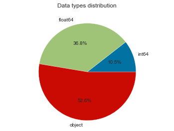

```python
plot_empirical_distribution(df.dtypes, var_type='quali', title='Data types')
```

## 1 - Numerical variable

```python
numerical_cols = df.select_dtypes(include=[float, int]).columns
print(f'Total numerical columns : {df[numerical_cols].shape[1]}')
df[numerical_cols].head(2)
```

```
Total numerical columns : 18
```

|  | payment_sequential | payment_installments | payment_value | review_score | geolocation_lat_customers | geolocation_lng_customers | order_item_qty | price | freight_value | product_name_lenght | product_description_lenght | product_photos_qty | product_weight_g | product_length_cm | product_height_cm | product_width_cm | geolocation_lat_sellers | geolocation_lng_sellers |
| --- | --- | --- | --- | --- | --- | --- | --- | --- | --- | --- | --- | --- | --- | --- | --- | --- | --- | --- |
| 0 | 1 | 2 | 146.87 | 4 | -23.560771 | -46.65925 | 1 | 124.99 | 21.88 | 41.0 | 1141.0 | 1.0 | 8683.0 | 54.0 | 64.0 | 31.0 | -23.548258 | -46.649825 |
| 1 | 1 | 8 | 94.77 | 5 | -23.560771 | -46.65925 | 1 | 79.90 | 14.87 | 54.0 | 245.0 | 1.0 | 1383.0 | 50.0 | 10.0 | 40.0 | -23.576881 | -46.695142 |

## 2 - Categorical variable

#### 2.1 - All categorical variable

```python
categorical_cols = df.select_dtypes(include=[object]).columns
print(f'Total categorical columns : {df[categorical_cols].shape[1]}')
df[categorical_cols].head(2)
```

```
Total categorical columns : 20
```

|  | customer_id | customer_city | customer_state | order_id | order_status | order_purchase_timestamp | order_approved_at | order_delivered_carrier_date | order_delivered_customer_date | order_estimated_delivery_date | payment_type | review_id | review_creation_date | review_answer_timestamp | seller_id | seller_city | seller_state | product_id | shipping_limit_date | product_category_name |
| --- | --- | --- | --- | --- | --- | --- | --- | --- | --- | --- | --- | --- | --- | --- | --- | --- | --- | --- | --- | --- |
| 0 | 861eff4711a542e4b93843c6dd7febb0 | franca | SP | 00e7ee1b050b8499577073aeb2a297a1 | delivered | 2017-05-16 15:05:35 | 2017-05-16 15:22:12 | 2017-05-23 10:47:57 | 2017-05-25 10:35:35 | 2017-06-05 00:00:00 | credit_card | 88b8b52d46df026a9d1ad2136a59b30b | 2017-05-26 00:00:00 | 2017-05-30 22:34:40 | 7c67e1448b00f6e969d365cea6b010ab | itaquaquecetuba | SP | a9516a079e37a9c9c36b9b78b10169e8 | 2017-05-22 15:22:12 | moveis_escritorio |
| 1 | 2761fee7f378f0a8d7682d8a3fa07ab1 | franca | SP | 95261f608a64bbbe760a212b4d48a4ee | delivered | 2018-06-15 20:07:13 | 2018-06-15 20:41:11 | 2018-06-18 15:52:00 | 2018-06-21 12:18:32 | 2018-07-05 00:00:00 | credit_card | 16a27e5ffd29a7cdf0e4984b0cab46b7 | 2018-06-22 00:00:00 | 2018-06-26 19:17:40 | 4a3ca9315b744ce9f8e9374361493884 | ibitinga | SP | 99a4788cb24856965c36a24e339b6058 | 2018-06-19 20:30:41 | cama_mesa_banho |

```python
dummy_cols = ['customer_city',
              'customer_state',
              'order_status',
              'payment_type',
              'seller_city',
              'seller_state',
              'product_category_name']
```

#### 2.2 - Datetime variable

```python
date_cols = [col for col in categorical_cols if col not in dummy_cols and col.endswith('_id') is False]
date_cols
```

```
['order_purchase_timestamp',
 'order_approved_at',
 'order_delivered_carrier_date',
 'order_delivered_customer_date',
 'order_estimated_delivery_date',
 'review_creation_date',
 'review_answer_timestamp',
 'shipping_limit_date']
```

```python
decompose_datetime(df, date_cols, convert_to_datetime=True, autodelete=True)
df.head(2)
```

|  | customer_id | customer_city | customer_state | order_id | order_status | payment_sequential | payment_type | payment_installments | payment_value | review_id | ... | review_answer_year | review_answer_month | review_answer_day | review_answer_hour | review_answer_ts | shipping_limit_year | shipping_limit_month | shipping_limit_day | shipping_limit_hour | shipping_limit_ts |
| --- | --- | --- | --- | --- | --- | --- | --- | --- | --- | --- | --- | --- | --- | --- | --- | --- | --- | --- | --- | --- | --- |
| 0 | 861eff4711a542e4b93843c6dd7febb0 | franca | SP | 00e7ee1b050b8499577073aeb2a297a1 | delivered | 1 | credit_card | 2 | 146.87 | 88b8b52d46df026a9d1ad2136a59b30b | ... | 2017 | 5 | 30 | 22 | 1496183680 | 2017 | 5 | 22 | 15 | 1495466532 |
| 1 | 2761fee7f378f0a8d7682d8a3fa07ab1 | franca | SP | 95261f608a64bbbe760a212b4d48a4ee | delivered | 1 | credit_card | 8 | 94.77 | 16a27e5ffd29a7cdf0e4984b0cab46b7 | ... | 2018 | 6 | 26 | 19 | 1530040660 | 2018 | 6 | 19 | 20 | 1529440241 |

2 rows × 70 columns

#### 2.2.1 - Analysis of the distribution of Datetime variable

```python
df_period = []
for period in ['year', 'month', 'day', 'hour']:
    gp_period = []
    for date_col in date_cols:
        rebuilt_col = "_".join(date_col.split('_')[:-1])
        gp_date_col = df.groupby(f'{rebuilt_col}_{period}')[f'{rebuilt_col}_{period}'].count()
        gp_period.append(gp_date_col)
    df_date_vars_period = pd.concat(gp_period, axis=1).fillna(0).astype(int)
    df_date_vars_period.index.set_names(period.capitalize(), inplace=True)
    df_period.append(df_date_vars_period)
```

```python
# Year (2016 and 2020 are underrepresented)
df_period[0].T
```

| Year | 2016 | 2017 | 2018 | 2020 |
| --- | --- | --- | --- | --- |
| order_purchase_year | 285 | 44611 | 53877 | 0 |
| order_approved_year | 285 | 44556 | 53932 | 0 |
| order_delivered_carrier_year | 285 | 44003 | 54485 | 0 |
| order_delivered_customer_year | 285 | 42086 | 56402 | 0 |
| order_estimated_delivery_year | 282 | 39888 | 58603 | 0 |
| review_creation_year | 285 | 42371 | 56117 | 0 |
| review_answer_year | 272 | 41709 | 56792 | 0 |
| shipping_limit_year | 285 | 43643 | 54844 | 1 |

```python
# Month
df_period[1].T
```

| Month | 1 | 2 | 3 | 4 | 5 | 6 | 7 | 8 | 9 | 10 | 11 | 12 |
| --- | --- | --- | --- | --- | --- | --- | --- | --- | --- | --- | --- | --- |
| order_purchase_month | 7926 | 8315 | 9769 | 9320 | 10592 | 9542 | 10340 | 10767 | 4268 | 4910 | 7442 | 5582 |
| order_approved_month | 7816 | 8292 | 9856 | 9125 | 10797 | 9544 | 10183 | 10952 | 4286 | 4872 | 7299 | 5751 |
| order_delivered_carrier_month | 7660 | 8095 | 9924 | 9215 | 10889 | 9582 | 9928 | 11558 | 4197 | 4855 | 6748 | 6122 |
| order_delivered_customer_month | 6953 | 7315 | 9367 | 9911 | 11180 | 10364 | 9591 | 12927 | 4120 | 4859 | 4859 | 7327 |
| order_estimated_delivery_month | 5537 | 6507 | 11334 | 8903 | 11058 | 8310 | 10641 | 13769 | 6370 | 4182 | 4826 | 7336 |
| review_creation_month | 6387 | 7418 | 10048 | 9292 | 11260 | 10236 | 9219 | 13423 | 4150 | 4611 | 4841 | 7888 |
| review_answer_month | 6426 | 7392 | 9747 | 9679 | 11144 | 9872 | 9503 | 13135 | 4737 | 4728 | 4698 | 7712 |
| shipping_limit_month | 7132 | 8019 | 9930 | 8754 | 11326 | 9538 | 9667 | 12255 | 4252 | 4819 | 6312 | 6769 |

```python
# Day
df_period[2]
```

| Day | order_purchase_day | order_approved_day | order_delivered_carrier_day | order_delivered_customer_day | order_estimated_delivery_day | review_creation_day | review_answer_day | shipping_limit_day |
| --- | --- | --- | --- | --- | --- | --- | --- | --- |
| 1 | 3118 | 3190 | 2240 | 2265 | 2836 | 2983 | 2779 | 2764 |
| 2 | 3193 | 3092 | 2964 | 2830 | 2864 | 2261 | 3259 | 2633 |
| 3 | 3251 | 3146 | 3241 | 3402 | 3068 | 2921 | 2935 | 2720 |
| 4 | 3441 | 2953 | 3307 | 3093 | 3235 | 3287 | 3051 | 2899 |
| 5 | 3391 | 3927 | 3183 | 3242 | 3873 | 2961 | 3113 | 3349 |
| 6 | 3380 | 3341 | 3550 | 3392 | 3839 | 3230 | 3220 | 2926 |
| 7 | 3354 | 3577 | 3534 | 3224 | 3182 | 3386 | 3241 | 3467 |
| 8 | 3306 | 3300 | 3384 | 3261 | 3540 | 3308 | 3111 | 3648 |
| 9 | 3238 | 3237 | 3432 | 3341 | 3295 | 3234 | 2963 | 3406 |
| 10 | 3140 | 3313 | 3253 | 3145 | 2732 | 3371 | 3439 | 3040 |
| 11 | 3303 | 3184 | 3038 | 3400 | 3224 | 3153 | 3285 | 3336 |
| 12 | 3180 | 3116 | 2531 | 2598 | 3062 | 3340 | 3116 | 3124 |
| 13 | 3221 | 3297 | 3203 | 3388 | 3410 | 2612 | 3186 | 3563 |
| 14 | 3350 | 3297 | 3569 | 3429 | 3318 | 3409 | 3152 | 3698 |
| 15 | 3497 | 3430 | 3312 | 3007 | 3033 | 3476 | 3227 | 3616 |
| 16 | 3590 | 3530 | 3842 | 3480 | 3619 | 3003 | 3260 | 2932 |
| 17 | 3196 | 3318 | 3479 | 3061 | 3037 | 3450 | 2877 | 3075 |
| 18 | 3449 | 3517 | 3010 | 3160 | 3117 | 3002 | 2966 | 3288 |
| 19 | 3359 | 3098 | 3497 | 3393 | 3438 | 3199 | 3055 | 3377 |
| 20 | 3251 | 3420 | 3692 | 3459 | 3646 | 3067 | 3594 | 3213 |
| 21 | 3102 | 2806 | 3355 | 3548 | 3262 | 3662 | 3555 | 3537 |
| 22 | 3131 | 2913 | 3243 | 3429 | 3321 | 3704 | 3402 | 3939 |
| 23 | 3105 | 2914 | 3512 | 3919 | 3509 | 3511 | 3580 | 3404 |
| 24 | 3874 | 4312 | 3304 | 3333 | 2944 | 3877 | 3492 | 2835 |
| 25 | 3262 | 3466 | 2577 | 2757 | 2354 | 3432 | 3495 | 2794 |
| 26 | 3281 | 3250 | 3200 | 3532 | 3212 | 2792 | 3550 | 3728 |
| 27 | 3117 | 3285 | 4173 | 3766 | 3155 | 3328 | 3338 | 3251 |
| 28 | 3008 | 3100 | 3163 | 3361 | 3356 | 3768 | 3332 | 2906 |
| 29 | 2531 | 2498 | 2699 | 2899 | 3273 | 3039 | 3081 | 3004 |
| 30 | 2500 | 2334 | 2671 | 2977 | 2981 | 2938 | 3108 | 3613 |
| 31 | 1654 | 1612 | 1615 | 1682 | 2038 | 2069 | 2011 | 1688 |

```python
# Hour
df_period[3]
```

| Hour | order_purchase_hour | order_approved_hour | order_delivered_carrier_hour | order_delivered_customer_hour | order_estimated_delivery_hour | review_creation_hour | review_answer_hour | shipping_limit_hour |
| --- | --- | --- | --- | --- | --- | --- | --- | --- |
| 0 | 2402 | 2003 | 2409 | 2942 | 98773 | 98690 | 6565 | 2157 |
| 1 | 1160 | 1522 | 1347 | 1532 | 0 | 83 | 5848 | 1442 |
| 2 | 507 | 6813 | 610 | 670 | 0 | 0 | 3769 | 6927 |
| 3 | 264 | 5331 | 266 | 260 | 0 | 0 | 2276 | 5353 |
| 4 | 208 | 3219 | 176 | 195 | 0 | 0 | 1104 | 3409 |
| 5 | 182 | 1003 | 292 | 201 | 0 | 0 | 544 | 869 |
| 6 | 480 | 900 | 698 | 282 | 0 | 0 | 402 | 904 |
| 7 | 1214 | 1450 | 1072 | 400 | 0 | 0 | 423 | 1365 |
| 8 | 2965 | 2280 | 1989 | 811 | 0 | 0 | 1013 | 2344 |
| 9 | 4732 | 3819 | 2564 | 1229 | 0 | 0 | 2566 | 4119 |
| 10 | 6103 | 4851 | 3197 | 1828 | 0 | 0 | 4854 | 4720 |
| 11 | 6531 | 5379 | 4166 | 2633 | 0 | 0 | 6840 | 5297 |
| 12 | 5959 | 4578 | 5520 | 3754 | 0 | 0 | 6271 | 4755 |
| 13 | 6441 | 5585 | 7645 | 4681 | 0 | 0 | 5312 | 5537 |
| 14 | 6501 | 5338 | 10708 | 5796 | 0 | 0 | 4849 | 5367 |
| 15 | 6373 | 5279 | 8979 | 6944 | 0 | 0 | 4262 | 5401 |
| 16 | 6634 | 5912 | 5794 | 8145 | 0 | 0 | 4176 | 5587 |
| 17 | 6077 | 5460 | 5673 | 8979 | 0 | 0 | 4233 | 5409 |
| 18 | 5737 | 5078 | 7022 | 9883 | 0 | 0 | 4374 | 4723 |
| 19 | 5942 | 5000 | 7711 | 9686 | 0 | 0 | 5093 | 4789 |
| 20 | 6184 | 4993 | 6806 | 9355 | 0 | 0 | 5094 | 5086 |
| 21 | 6205 | 4715 | 5581 | 7772 | 0 | 0 | 5992 | 4826 |
| 22 | 5818 | 4697 | 4766 | 6276 | 0 | 0 | 5872 | 4800 |
| 23 | 4154 | 3568 | 3782 | 4519 | 0 | 0 | 7041 | 3587 |

```python
# Clean up (filter & delete)
date_cols_year = ["_".join(col.split('_')[:-1])+'_year' for col in date_cols]
df = df[~df[date_cols_year].isin([2016, 2020]).any(axis=1)]
delete_cols(df, 'order_estimated_delivery_hour')
```

# III - Feature engineering

## 1 - Sellers

#### 1.1 - Variable which concerns the total number of orders per seller

```python
# create variable which concerns the total number of orders per seller
total_orders_per_seller = dict(df.groupby('seller_id')['order_id'].count())
df['seller_total_orders'] = df['seller_id'].map(total_orders_per_seller)
```

#### 1.2 - Variable which concerns the total number of products sold per seller

```python
# create variable which concerns the total number of products sold per seller
sgp = df.groupby(['seller_id', 'product_id', 'order_item_qty'])['product_id'].count().to_frame()
# N.B : order_item_id is the quantity of items ordered for each order.
# (see : https://www.kaggle.com/olistbr/brazilian-ecommerce?select=olist_order_items_dataset.csv)
# We multiply this quantity by the number of products ordered
sgp['total_products_sold'] = sgp.index.get_level_values('order_item_qty') * sgp['product_id']
total_products_sold_per_seller = dict(sgp.groupby(level=['seller_id'])['total_products_sold'].sum())
df['seller_total_products_sold'] = df['seller_id'].map(total_products_sold_per_seller)
```

#### 1.3 - Variable which concerns the proportion of products sold in a single quantity compared to the total sold

```python
# 1 => all products sold were purchased in a single quantity
df['seller_uniq_products_sold_ratio'] = np.round(df['seller_total_orders'] / df['seller_total_products_sold'], 2)
```

#### 1.4 - Variable which normalize freight value for each item sold

```python
# Item freight value item (if an order has more than one item the freight value is splitted between items)
df['freight_value_per_item'] = df['freight_value'] / df['order_item_qty']
```

#### 1.5 - Variables which count (unique & total) customers per seller

```python
seller_gp_customers = df.groupby('seller_id')['customer_id']
df['seller_uniq_customers_ct'] = df['seller_id'].map(dict(seller_gp_customers.nunique()))
df['seller_total_customers_ct'] = df['seller_id'].map(dict(seller_gp_customers.count()))
df['seller_uniq_customers_ratio'] = np.round(df['seller_uniq_customers_ct'] / df['seller_total_customers_ct'], 2)
```

#### 1.6 - Variables which count recurring (total & ratio) customers per seller

```python
df['seller_total_recurring_customers_ct'] = df['seller_total_customers_ct'] - df['seller_uniq_customers_ct']
recurr_customers_per_seller_ratio = df['seller_total_recurring_customers_ct'] / df['seller_total_customers_ct']
df['seller_recurring_customers_ratio'] = np.round(recurr_customers_per_seller_ratio, 2)
```

## 2 - Customers

#### 2.1 - Variable which concerns the total number of orders per customer

```python
total_orders_per_customer = dict(df.groupby('customer_id')['order_id'].count())
df['customer_total_orders'] = df['customer_id'].map(total_orders_per_customer)
```

#### 2.2 - Variable which concerns the total number of products purchased per customer

```python
cgp = df.groupby(['customer_id', 'product_id', 'order_item_qty'])['product_id'].count().to_frame()
# We multiply this quantity by the number of products ordered
cgp['total_products_purchased'] = cgp.index.get_level_values('order_item_qty') * cgp['product_id']
total_products_purchased_per_cust = dict(cgp.groupby(level=['customer_id'])['total_products_purchased'].sum())
df['customer_total_products_purchased'] = df['customer_id'].map(total_products_purchased_per_cust)
```

#### 2.3 - Variable which concerns the proportion of products purchased in a single quantity compared to the total orders

```python
# 1 => all ordered products were purchased in a single quantity
# 0.90 => 90% of products were sold only once
cust_uniq_products_purchased_ratio = df['customer_total_orders'] / df['customer_total_products_purchased']
df['cust_uniq_products_purchased_ratio'] = np.round(cust_uniq_products_purchased_ratio, 2)
```

#### 2.4 - Variables which count recurring (total, ratio) products purchased per customer

```python
# First get the list of products purchased by customers
cust_products_gp = df.groupby('customer_id')['product_category_name'].apply(list).reset_index(name='products')
# Build a lambda function which get the total of recurring products purchased by a customer
get_customer_recurring_products_ct = lambda p: 0 if len(p) == 1 else pd.Series(p).duplicated().sum()
# Map lambda function to groupby dataframe
cust_products_gp['cust_recurr_products_ct'] = cust_products_gp['products'].map(get_customer_recurring_products_ct)
# Build dictionary which selects main needed variables from groupby dataframe
cust_recurr_products_gp_ct_dict = dict(cust_products_gp[['customer_id', 'cust_recurr_products_ct']].values)
# Map dictionary to main cleaned dataset
df['customer_recurring_products_purchased_ct'] = df['customer_id'].map(cust_recurr_products_gp_ct_dict)
# Compute recurring products purchased ratio based on the total of products ordered
# (= not standardized by order item quantity)
cust_recurr_products_ratio = df['customer_recurring_products_purchased_ct'] / df['customer_total_orders']
df['customer_recurring_products_purchased_ratio'] = np.round(cust_recurr_products_ratio, 2)
```

#### 2.5 - Variable which get the most recurring product purchased by a customer

```python
# Build a lambda function which get the most recurring product purchased by a customer
get_customer_recurring_product = lambda p: 'no_recurring_product' if len(p) == 1 else pd.Series(p).mode()[0]
# Map lambda function to groupby dataframe
cust_products_gp['most_recurr_product'] = cust_products_gp['products'].map(get_customer_recurring_product)
# Build dictionary which selects main needed variables from groupby dataframe
cust_recurr_product_gp_dict = dict(cust_products_gp[['customer_id', 'most_recurr_product']].values)
# Map dictionary to main cleaned dataset
df['most_recurring_product_purchased'] = df['customer_id'].map(cust_recurr_product_gp_dict)
```

#### 2.6 - Variables which count (unique & total) sellers per customer

```python
customer_gp_sellers = df.groupby('customer_id')['seller_id']
df['customer_uniq_sellers_ct'] = df['customer_id'].map(dict(customer_gp_sellers.nunique()))
df['customer_total_sellers_ct'] = df['customer_id'].map(dict(customer_gp_sellers.count()))
df['customer_uniq_sellers_ratio'] = np.round(df['customer_uniq_sellers_ct'] / df['customer_total_sellers_ct'], 2)
```

#### 2.7 - Variables which count recurring (total & ratio) sellers per customer

```python
df['customer_total_recurring_sellers_ct'] = df['customer_total_sellers_ct'] - df['customer_uniq_sellers_ct']
recurr_sellers_per_customer_ratio = df['customer_total_recurring_sellers_ct'] / df['customer_total_sellers_ct']
df['customer_recurring_sellers_ratio'] = np.round(recurr_sellers_per_customer_ratio, 2)
```

#### 2.8 - Variable which build a customer loyalty indicator

```python
cust_loyalty_ind = df['customer_total_recurring_sellers_ct'] / df['customer_uniq_sellers_ct']
df['customer_loyalty_indicator'] = np.round(cust_loyalty_ind, 2)
```

```python
df.shape
```

```
(98487, 90)
```

#### 2.9 - Variables which concerns :

- the total number of **orders per customer per year, quarter, month**
- the total number of **payments per customer per year, quarter, month**

```python
%%time

# Define time scale
time_scale = ['year', 'quarter', 'month']
baseline_total_var_ct = df.shape[1]
for ts in time_scale:
    initial_total_var_ct = df.shape[1]
    df = decompose_variable_by_time_scale(df, ts)
    end_total_var_ct = df.shape[1]
    total_var_ct = percentage_change(initial_total_var_ct, end_total_var_ct, precision=1)
    print(f'Total variable count increase by {total_var_ct}% {initial_total_var_ct} --> {end_total_var_ct}')
```

```
Total variable count increase by 14.4% 90 --> 103
Total variable count increase by 42.7% 103 --> 147
Total variable count increase by 49.0% 147 --> 219
CPU times: user 6min 23s, sys: 13.5 s, total: 6min 37s
Wall time: 6min 38s
```

```python
total_var_ct = percentage_change(baseline_total_var_ct, df.shape[1], precision=1)
print(f'Total variable count increase by {total_var_ct}% {baseline_total_var_ct} --> {df.shape[1]}')
```

```
Total variable count increase by 143.3% 90 --> 219
```

#### 3 - Variable which define customer distance from Sao Paulo (in km or m)

```python
# https://geocoder.readthedocs.io/api.html#forward-geocoding

sao_paulo_coords = geocoder.osm('Sao Paulo').latlng

customer_coords_cols = ['geolocation_lat_customers', 'geolocation_lng_customers']

df['customer_dist_km'] = df[customer_coords_cols].apply(lambda coords: get_geodesic_dist(coords,
                                                                                         sao_paulo_coords,
                                                                                         unit='km'), axis=1)
```

```python
len(df['customer_dist_km'].unique())
```

```
11583
```

#### 3.1 - Variable which define customer total payment sequential operations

```python
# Prepare payment sequential data

# Rappel : a customer may pay an order with more than 1 payment method. If he does so, a sequence
#          will be created to accommodate all payments.

payment_seq_per_customer = df.groupby(['customer_id', 'order_id'])['payment_sequential'].apply(list)

payment_seq_per_customer = payment_seq_per_customer.reset_index(name='payment_seq_list')

payment_seq_per_customer['total_payment_sequential'] = payment_seq_per_customer['payment_seq_list'].map(len)

# payment_seq_per_customer['total_payment_sequential']

payment_seq_per_customer.set_index('customer_id', inplace=True)

df = df.join(payment_seq_per_customer.loc[:, 'total_payment_sequential'], on='customer_id')
#payment_seq_per_customer_dict = dict(payment_seq_per_customer['total_payment_sequential'])

#df.loc[:, 'total_payment_sequential'] = df.loc[:, 'customer_id'].map(payment_seq_per_customer_dict)

print(df.shape)

# Check duplicates
df.drop_duplicates(subset=['customer_id', 'order_id', 'order_purchase_ts'], inplace=True)

print(df.shape)
```

```
(105882, 221)
(94858, 221)
```

```python
#df.loc[:, 'total_payment_sequential'] = df.loc[:, 'total_payment_sequential'].astype(int)
```

## 3 - Transaction times

#### 3.1 - Variable which concerns order approved delay (in minutes)

```python
order_approved_delay = df['order_approved_ts'] - df['order_purchase_ts']
df['order_approved_delay_in_min'] = pd.to_datetime(order_approved_delay, unit='s').dt.minute
```

#### 3.2 - Variable which concerns order delivered carrier delay (in day)

```python
order_delivered_carrier_delay = df['order_delivered_carrier_ts'] - df['order_purchase_ts']
df['order_delivered_carrier_delay_in_day'] = pd.to_datetime(order_delivered_carrier_delay, unit='s').dt.day
```

#### 3.3 - Variable which concerns order delivered customer delay starting from carrier (in day)

```python
order_delivered_cust_delay_from_carrier = df['order_delivered_customer_ts'] - df['order_delivered_carrier_ts']
df['order_delivered_cust_delay_from_carrier_in_day'] = pd.to_datetime(order_delivered_cust_delay_from_carrier,
                                                                      unit='s').dt.day
```

#### 3.4 - Variable which concerns order delivered customer delay starting from purchase (in day)

```python
order_delivered_cust_delay_from_purchase = df['order_delivered_customer_ts'] - df['order_purchase_ts']
df['order_delivered_cust_delay_from_purchase_in_day'] = pd.to_datetime(order_delivered_cust_delay_from_purchase,
                                                                      unit='s').dt.day
```

#### 3.5 - Variables which concerns difference between :

- **order delivered customer** and **order estimated delivery delays** (in day)
- **order delivered carrier** and **order shipping limit delays** (in day)

```python
order_delivered_cust_delay_from_estim = df['order_estimated_delivery_ts'] - df['order_delivered_customer_ts']

# Rappel => shipping_limit_date :
# - Shows the seller shipping limit date for handling the order over to the logistic partner.
# (see : https://www.kaggle.com/olistbr/brazilian-ecommerce?select=olist_order_items_dataset.csv)

order_delivered_carr_delay_from_shipping_lim = df['shipping_limit_ts'] - df['order_delivered_carrier_ts']

#
order_delivered_delay_eval_dict = {'overvalued': lambda v: v if v > 0 else 0,
                                   'undervalued': lambda v: v if v < 0 else 0,
                                   'matched': lambda v: v if v == 0 else 0}
#
for estim_type, estim_function in order_delivered_delay_eval_dict.items():
    cust_label = f'{estim_type}_order_delivered_cust_delay_in_days'
    carr_label = f'{estim_type}_order_delivered_carrier_delay_from_limit_in_day'
    df[cust_label] = pd.to_datetime(order_delivered_cust_delay_from_estim.map(estim_function), unit='s').dt.day
    df[carr_label] = pd.to_datetime(order_delivered_carr_delay_from_shipping_lim.map(estim_function),
                                    unit='s').dt.day
```

#### 3.6 - Variable that classifies the ability to predict delivery dates

```python
#

df['estimated_delivery_eval'] = order_delivered_cust_delay_from_estim.map(eval_delivery_date)
# To do : transform as indicator (get_dummies)
```

#### 3.7 - Variable which concerns order shipping limit date reached (binary variable)

```python
df['shipping_limit_date_reached'] = order_delivered_carr_delay_from_shipping_lim.map(lambda v: 0 if v >=0 else 1)
# df['shipping_limit_date_reached'].head(2)
```

```python
# Build subset for EDA
eda = df.copy()
id_cols = [col for col in eda.columns if col.endswith('id') and col not in ['customer_id', 'order_id']]
delete_cols(eda, id_cols)
```

```python
eda.shape
```

```
(94858, 230)
```

#### 3.8 - Variable which translate product category name in english

```python
# Import product category name translation csv file
df_translator = pd.read_csv('../data/csv/product_category_name_translation.csv')
# Get unique product names from translation dataframe
translator_unique_prod_pt = df_translator.product_category_name
# Get unique product names from EDA dataframe
unique_prod_pt = pd.Series(eda.product_category_name.unique())
# Check if unique product names length are equal
len(translator_unique_prod_pt) == len(unique_prod_pt)
```

```
False
```

```python
# Find missing product category names
missing_prod_name_pt = unique_prod_pt[~unique_prod_pt.isin(translator_unique_prod_pt)].values.tolist()
print(missing_prod_name_pt)
# Assign product category to missing product
missing_prod_name = {'product_category_name': missing_prod_name_pt,
                     'product_category_name_english': ['la_cuisine', 'computers']}
df_translator.append(pd.DataFrame(missing_prod_name), ignore_index=True)

eda['product_category_name_en'] = eda['product_category_name'].map(dict(df_translator.values))
```

```
['portateis_cozinha_e_preparadores_de_alimentos', 'pc_gamer']
```

# IV - EDA

```python
eda.head(2)
```

|  | customer_id | customer_city | customer_state | order_id | order_status | payment_sequential | payment_type | payment_installments | payment_value | review_score | ... | order_delivered_cust_delay_from_purchase_in_day | overvalued_order_delivered_cust_delay_in_days | overvalued_order_delivered_carrier_delay_from_limit_in_day | undervalued_order_delivered_cust_delay_in_days | undervalued_order_delivered_carrier_delay_from_limit_in_day | matched_order_delivered_cust_delay_in_days | matched_order_delivered_carrier_delay_from_limit_in_day | estimated_delivery_eval | shipping_limit_date_reached | product_category_name_en |
| --- | --- | --- | --- | --- | --- | --- | --- | --- | --- | --- | --- | --- | --- | --- | --- | --- | --- | --- | --- | --- | --- |
| 0 | 861eff4711a542e4b93843c6dd7febb0 | franca | SP | 00e7ee1b050b8499577073aeb2a297a1 | delivered | 1 | credit_card | 2 | 146.87 | 4 | ... | 9 | 11 | 1 | 1 | 31 | 1 | 1 | overvalued | 1 | office_furniture |
| 1 | 2761fee7f378f0a8d7682d8a3fa07ab1 | franca | SP | 95261f608a64bbbe760a212b4d48a4ee | delivered | 1 | credit_card | 8 | 94.77 | 5 | ... | 6 | 14 | 2 | 1 | 1 | 1 | 1 | overvalued | 0 | bed_bath_table |

2 rows × 231 columns

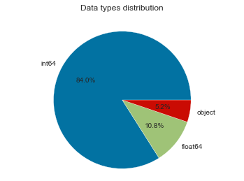

```python
plot_empirical_distribution(eda.dtypes, var_type='quali', title='Data types')
```